# Building an ETL Pipeline for the Monthly Retail Trade Survey (MRTS)

**Ashwin Pal**

# Index

- Abstract
- 1. Introduction
- 2. Extract-Transform-Load
  - 2.1 The ETL Process
  - 2.2 Data Exploration
  - 2.3 Data Preparation
  - 2.4 Read the Data Using Python
    - 2.4.1 Reading Sample Data
    - 2.4.2 Reading the MRST Data
  - 2.5 Writing an Installation Script
- 3. Analysis and Visualization
  - 3.1 Running Queries in MySQL Workbech
  - 3.2 Running Queries From Python
  - 3.3 Explore Trends
  - 3.4 Explore Percentage Change
  - 3.5 Explore Rolling Time Windows
- Conclusion
- References

Back to top

Back to top

## 1. Introduction

This approach shows how ETL pipelines not only prepare raw survey data for structured use but also provide a foundation for deeper exploration of economic trends, seasonality, and forecasting. **The final analysis demonstrated that grocery stores consistently lead in spending growth, while other categories such as bookstores and men’s clothing have steadily declined, reflecting long-term structural changes in consumer behavior.**

Back to top

## 2. Extract-Transform-Load

Back to top

### 2.1 The ETL Process

The ETL pipeline for MRTS involved three steps:

- Extract – Retrieved raw monthly sales data from yearly Excel worksheets. Each sheet included NAICS codes, business categories, and sales totals.
- Transform – Reformatted dates into YYYY-MM, converted sales values to numeric types, handled nulls, and standardized text entries. The data was reshaped into a long format where each record represents a business category’s sales in a given month. A small sample CSV was generated for testing alongside the full dataset.
- Load – Exported the cleaned dataset into CSV, then used Python scripts with mysql.connector to create a MySQL database and populate it. This ensured efficient storage and easy querying for time-series analysis.

Back to top

### 2.2 Data Exploration

Exploration of the cleaned dataset revealed:

- Over 23,000 records representing monthly sales values.
- Sales highly concentrated in certain sectors (e.g., motor vehicles, food, general merchandise).
- Seasonal peaks in December and declines during recessions or crises.
- Right-skewed distribution, with a few categories generating disproportionately large sales.

This exploration confirmed the dataset’s richness for studying retail growth, sectoral variation, and seasonality.

The MRTS dataset provides retail sales data in two different formats: **not adjusted** (raw values) and seasonally **adjusted**. Each has strengths and weaknesses depending on the type of analysis being performed.

The **not adjusted** values are the original raw data as reported. These numbers are useful because they capture the real seasonal patterns in consumer spending. For example, December always shows a spike due to holiday shopping, while other months may dip. However, the downside is that these seasonal swings can hide long-term economic trends, making it harder to compare sales across months on an equal basis.

The **adjusted** values have already been processed to remove those seasonal effects. This makes it easier to identify the underlying trends in the economy and to compare different months directly. Economists often prefer this version because it smooths out predictable fluctuations. The drawback is that some information about actual seasonal behavior is lost, and the adjustments rely on statistical models that may introduce assumptions.

Back to top

### 2.3 Data Preparation

This resulted in a clean, consistent dataset that could support both SQL queries and visual analytics.

Back to top

### 2.4 Read the Data Using Python

Python’s pandas library provides straightforward tools for reading CSV files. Using pd.read_csv("**full_mrtssales.csv**"), the MRTS dataset was loaded into a DataFrame, enabling quick inspection with **.head()**, **.info()**, and **.describe()**. This allowed efficient validation of data types, missing values, and column structure.

A sample CSV file was first used to test the reading and transformation steps before applying the workflow to the full dataset. Once validated, the full MRTS CSV was imported into both Python and MySQL, ensuring consistency across tools.

```python
import numpy as np
import pandas as pd
import re

import matplotlib.pyplot as plt
import seaborn as sns

import mysql.connector as mc
```

```python
import warnings
warnings.filterwarnings("ignore", category=FutureWarning)
```

- Loop through each sheet
- Grab the month headers from row 5
- Grab the sales values from rows 7 to 110
- Grab the NAICS Code and Kind of Business from columns A & B
- For each month column, pair every row’s NAICS, Business, Month, and its sales value.
- Store all as records, then turn into one big DataFrame.
- Recommended download excel as csv
- And Use Not Adjusted & Adjusted items

```python
# Not Adjusted and Adjusted Combined

PATH = "3 mrtssales92present.xls"
xls  = pd.ExcelFile(PATH, engine="xlrd")

def month_slice(year):
    # Excel column indices: C=2..N=13 for 1992–2020, C=2..F=5 for 2021
    return slice(2, 14) if year != 2021 else slice(2, 6)

records = []

for s in xls.sheet_names:
    if not str(s).isdigit():
        continue
    year = int(s)
    sheet = pd.read_excel(PATH, sheet_name=s, header=None, engine="xlrd")

    # header labels for months (Excel row 5 = index 4)
    cols = month_slice(year)
    headers = sheet.iloc[4, cols].astype(str).tolist()

    # data rows (Excel 7..110 = index 6..110)
    block = sheet.iloc[6:110, cols].replace(",", "", regex=True).apply(pd.to_numeric, errors="coerce")

    # id columns (A = 0, B = 1)
    naics_codes = sheet.iloc[6:110, 0].astype(str).tolist()
    kind_of_business = sheet.iloc[6:110, 1].astype(str).tolist()

    # for each month column
    for idx, h in enumerate(headers):
        label = re.sub(r"\.\s*", " ", h).strip()  # e.g., "Jan. 2000" -> "Jan 2000"
        try:
            # Parse into datetime, then format as YYYY-MM
            date_val = pd.to_datetime(label, format="%b %Y", errors="coerce")
            if pd.notna(date_val):
                date_val = date_val.strftime("%Y-%m")
        except:
            date_val = None

        col_vals = block.iloc[:, idx].tolist()
        for code, business, val in zip(naics_codes, kind_of_business, col_vals):
            records.append({
                "NAICS CODE": code,
                "Kind of Business": business,
                "YYYY_MM": date_val,
                "Total_Sales": val
            })

# Final DataFrame
df = pd.DataFrame.from_records(records)

# Clean up
df = df.dropna(subset=["Total_Sales"]).reset_index(drop=True)
```

> OpenAI. (2025). *ChatGPT (Mar 2025 version)* [Large language model]. OpenAI. https://chat.openai.com/

```python
df.sample(5)
```

|  | NAICS CODE | Kind of Business | YYYY_MM | Total_Sales |
| --- | --- | --- | --- | --- |
| 3550 | 444 | Building mat. and garden equip. and supplies d... | 2018-09 | 29354.0 |
| 29590 | nan | Retail sales and food services excl gasoline s... | 1997-12 | 254683.0 |
| 20161 | nan | Retail sales and food services excl gasoline s... | 2004-02 | 286137.0 |
| 32648 | 4441 | Building mat. and supplies dealers | 1994-07 | 11852.0 |
| 18093 | 45431 | Fuel dealers | 2006-06 | 2294.0 |

```python
# Save to Excel (one sheet, no index column)
df.to_excel("mrtssales_long.xlsx", index=False)
```

```python
# df = pd.read_excel("mrtssales_long.xlsx")
```

### Data Overview

```python
df1 = df.copy()
```

```python
df.shape
```

```
(35567, 4)
```

```python
df.info()
```

```
<class 'pandas.core.frame.DataFrame'>
RangeIndex: 35567 entries, 0 to 35566
Data columns (total 4 columns):
 #   Column            Non-Null Count  Dtype
---  ------            --------------  -----
 0   NAICS CODE        35567 non-null  object
 1   Kind of Business  35567 non-null  object
 2   YYYY_MM           35349 non-null  object
 3   Total_Sales       35567 non-null  float64
dtypes: float64(1), object(3)
memory usage: 1.1+ MB
```

```python
df.nunique()
```

```
NAICS CODE             59
Kind of Business       68
YYYY_MM               349
Total_Sales         24424
dtype: int64
```

Null Values

```python
df.isnull().sum().sum()
```

```
np.int64(218)
```

```python
df.isnull().sum() # df.isna().sum()
```

```
NAICS CODE            0
Kind of Business      0
YYYY_MM             218
Total_Sales           0
dtype: int64
```

```python
(df.isna().sum() / len(df)) * 100   # percentage missing
```

```
NAICS CODE          0.000000
Kind of Business    0.000000
YYYY_MM             0.612928
Total_Sales         0.000000
dtype: float64
```

Duplicated Rows

```python
df.duplicated().sum().sum()
```

```
np.int64(38)
```

```python
df
```

|  | NAICS CODE | Kind of Business | YYYY_MM | Total_Sales |
| --- | --- | --- | --- | --- |
| 0 | nan | Retail and food services sales, total | 2021-01 | 517119.0 |
| 1 | nan | Retail sales and food services excl motor vehi... | 2021-01 | 412864.0 |
| 2 | nan | Retail sales and food services excl gasoline s... | 2021-01 | 479905.0 |
| 3 | nan | Retail sales and food services excl motor vehi... | 2021-01 | 375650.0 |
| 4 | nan | Retail sales, total | 2021-01 | 464362.0 |
| ... | ... | ... | ... | ... |
| 35562 | 453 | Miscellaneous stores retailers | 1992-12 | 5059.0 |
| 35563 | 454 | Nonstore retailers | 1992-12 | 6597.0 |
| 35564 | 4541 | Electronic shopping and mail order houses | 1992-12 | 3032.0 |
| 35565 | 45431 | Fuel dealers | 1992-12 | 1444.0 |
| 35566 | 722 | Food services and drinking places | 1992-12 | 17491.0 |

35567 rows × 4 columns

### Data Cleaning

```python
df = df[["Kind of Business", "YYYY_MM", "Total_Sales"]]
df.head()
```

|  | Kind of Business | YYYY_MM | Total_Sales |
| --- | --- | --- | --- |
| 0 | Retail and food services sales, total | 2021-01 | 517119.0 |
| 1 | Retail sales and food services excl motor vehi... | 2021-01 | 412864.0 |
| 2 | Retail sales and food services excl gasoline s... | 2021-01 | 479905.0 |
| 3 | Retail sales and food services excl motor vehi... | 2021-01 | 375650.0 |
| 4 | Retail sales, total | 2021-01 | 464362.0 |

```python
df["Kind of Business"].astype(str).str.len().max()
```

```
81
```

#### Null Values

```python
df.isnull().sum().sum()
```

```
np.int64(218)
```

```python
# Drop any rows where Month_Year or Total_Sales is missing
df = df.dropna(subset=["Kind of Business", "YYYY_MM", "Total_Sales"])
df.isnull().sum().sum()
```

```
np.int64(0)
```

#### Duplicated Values

```python
df.duplicated().sum()
```

```
np.int64(38)
```

```python
df
```

|  | Kind of Business | YYYY_MM | Total_Sales |
| --- | --- | --- | --- |
| 0 | Retail and food services sales, total | 2021-01 | 517119.0 |
| 1 | Retail sales and food services excl motor vehi... | 2021-01 | 412864.0 |
| 2 | Retail sales and food services excl gasoline s... | 2021-01 | 479905.0 |
| 3 | Retail sales and food services excl motor vehi... | 2021-01 | 375650.0 |
| 4 | Retail sales, total | 2021-01 | 464362.0 |
| ... | ... | ... | ... |
| 35562 | Miscellaneous stores retailers | 1992-12 | 5059.0 |
| 35563 | Nonstore retailers | 1992-12 | 6597.0 |
| 35564 | Electronic shopping and mail order houses | 1992-12 | 3032.0 |
| 35565 | Fuel dealers | 1992-12 | 1444.0 |
| 35566 | Food services and drinking places | 1992-12 | 17491.0 |

35349 rows × 3 columns

```python
# number of distinct values
distinct_count = df["Kind of Business"].nunique()
print("Number of distinct values:", distinct_count)

# show distinct values
distinct_values = df["Kind of Business"].unique()
print("Distinct values:", distinct_values)

# optional: show them with counts (frequency)
value_counts = df["Kind of Business"].value_counts()
print(value_counts)
```

```
Number of distinct values: 68
Distinct values: ['Retail and food services sales, total'
 'Retail sales and food services excl motor vehicle and parts'
 'Retail sales and food services excl gasoline stations'
 'Retail sales and food services excl motor vehicle and parts and gasoline stations'
 'Retail sales, total'
 'Retail sales, total (excl. motor vehicle and parts dealers)' 'GAFO(1)'
 'Motor vehicle and parts dealers'
 'Automobile and other motor vehicle dealers' 'Automobile dealers'
 'New car dealers' 'Used car dealers'
 'Automotive parts, acc., and tire stores'
 'Furniture, home furn, electronics, and appliance stores'
 'Furniture and home furnishings stores' 'Furniture stores'
 'Electronics and appliance stores' 'Household appliance stores'
 'Electronics stores'
 'Building mat. and garden equip. and supplies dealers'
 'Building mat. and supplies dealers' 'Paint and wallpaper stores'
 'Hardware stores' 'Food and beverage stores' 'Grocery stores'
 'Supermarkets and other grocery (except convenience) stores'
 'Beer, wine, and liquor stores' 'Health and personal care stores'
 'Pharmacies and drug stores' 'Gasoline stations'
 'Clothing and clothing access. stores' 'Clothing stores'
 "Men's clothing stores" "Women's clothing stores"
 'Family clothing stores' 'Other clothing stores' 'Shoe stores'
 'Jewelry stores'
 'Sporting goods, hobby, musical instrument, and book stores'
 'Sporting goods stores' 'Hobby, toy, and game stores' 'Book stores'
 'General merchandise stores' 'Department stores'
 'Department stores(excl. discount department stores)'
 'Discount dept. stores' 'Other general merchandise stores'
 'Warehouse clubs and superstores' 'All other gen. merchandise stores'
 'Miscellaneous store retailers'
 'Office supplies, stationery, and gift stores'
 'Office supplies and stationery stores'
 'Gift, novelty, and souvenir stores' 'Used merchandise stores'
 'Nonstore retailers' 'Electronic shopping and mail-order houses'
 'Fuel dealers' 'Food services and drinking places'
 'Restaurants and other eating places' 'Limited service eating places'
 'Beer, wine and liquor stores' 'Miscellaneous stores retailers'
 'Electronic shopping and mail order houses' 'Home furnishings stores'
 'All other home furnishings stores' 'Full service restaurants'
 'Drinking places' 'Floor covering stores']
Kind of Business
Retail and food services sales, total                                                698
Retail sales and food services excl motor vehicle and parts                          698
Retail sales and food services excl gasoline stations                                698
Retail sales and food services excl motor vehicle and parts and gasoline stations    698
Retail sales, total                                                                  698
                                                                                    ...
Electronics stores                                                                   289
Other clothing stores                                                                241
Supermarkets and other grocery (except convenience) stores                           241
Paint and wallpaper stores                                                           241
All other home furnishings stores                                                    237
Name: count, Length: 68, dtype: int64
```

```python
# Count number of distinct 'Kind of Business' values
distinct_count = df["Kind of Business"].nunique()

# Store distinct values of 'Kind of Business'
distinct_values = df["Kind of Business"].unique()

# Count frequency of each distinct 'Kind of Business'
value_counts = df["Kind of Business"].value_counts()

# ================================
# Keep only distinct 'Kind of Business' per 'YYYY_MM'
# If there are duplicates with the same 'Kind of Business' + 'YYYY_MM',
# aggregate them by summing numeric columns
# ================================
df = df.groupby(["Kind of Business", "YYYY_MM"], as_index=False).sum()

# Check if any fully duplicated rows remain
remaining_duplicates = df.duplicated().sum()
```

```python
df
```

|  | Kind of Business | YYYY_MM | Total_Sales |
| --- | --- | --- | --- |
| 0 | All other gen. merchandise stores | 1992-01 | 4793.0 |
| 1 | All other gen. merchandise stores | 1992-02 | 4770.0 |
| 2 | All other gen. merchandise stores | 1992-03 | 4722.0 |
| 3 | All other gen. merchandise stores | 1992-04 | 4968.0 |
| 4 | All other gen. merchandise stores | 1992-05 | 4993.0 |
| ... | ... | ... | ... |
| 23131 | Women's clothing stores | 2020-09 | 5217.0 |
| 23132 | Women's clothing stores | 2020-10 | 5211.0 |
| 23133 | Women's clothing stores | 2020-11 | 5175.0 |
| 23134 | Women's clothing stores | 2020-12 | 5926.0 |
| 23135 | Women's clothing stores | 2021-01 | 4808.0 |

23136 rows × 3 columns

```python
df.shape
```

```
(23136, 3)
```

### Exploratory Data Analytis (EDA)

#### Summary Statistics

```python
# Start with describe
summary = df.describe().T

# Add ratio and skewness-like metric
summary["ratio"] = summary["std"] / summary["mean"]
summary["skew"]  = summary["std"] / summary["mean"]   # (you might replace this with actual df.skew())

# Format Month_Year stats nicely as MMM YYYY
for col in ["min", "25%", "50%", "75%", "max"]:
    if pd.api.types.is_datetime64_any_dtype(df["YYYY_MM"]):
        summary.loc["YYYY_MM", col] = pd.to_datetime(summary.loc["YYYY_MM", col]).strftime("%b %Y")

summary
```

|  | count | mean | std | min | 25% | 50% | 75% | max | ratio | skew |
| --- | --- | --- | --- | --- | --- | --- | --- | --- | --- | --- |
| Total_Sales | 23136.0 | 76300.71473 | 168723.637288 | 11.0 | 3482.0 | 13026.0 | 52826.75 | 1147401.0 | 2.211298 | 2.211298 |

Observations on Sales Data

[output not shown]

```python
# for col in df.select_dtypes(include=["object", "string"]).columns:
#     print(f"\n--- {col} ---")
#     print(df["Kind of Business"].value_counts().head(10))
```

[figure not shown]

```python
plt.figure(figsize=(12,6))
plt.plot(df["YYYY_MM"], df["Total_Sales"], marker="o", linewidth=1)
plt.title("Total Sales Over Time", fontsize=14)
plt.xlabel("YYYY_MM")
plt.ylabel("Total Sales")
plt.grid(True)
plt.tight_layout()
plt.show()
```

Insights from Total Sales Over Time

```
The sales data shows a strong upward trend, but also clear differences between business groups. While most categories follow steady growth, there are seasonal spikes, occasional shocks, and a few businesses that reach much higher levels than others.
```

Key takeaways:

- Overall Growth → Total sales have been increasing steadily over time, showing positive long-term momentum across business categories.
- Seasonality → Noticeable spikes occur in certain months, likely tied to holidays or yearly shopping events, before returning to regular levels.
- Volatility & Shocks → Some months show sudden jumps or dips, indicating unexpected shocks or irregular events affecting sales.
- Business Group Clusters → The chart reveals layers of businesses, where some categories consistently sell far more than others, forming distinct bands.
- Recent Highs → In the most recent periods, sales are reaching their highest recorded levels, suggesting continued growth and strong market performance.
- Outliers → A few months stand out with extremely high sales values, far above the usual trend, pulling the overall distribution upward.

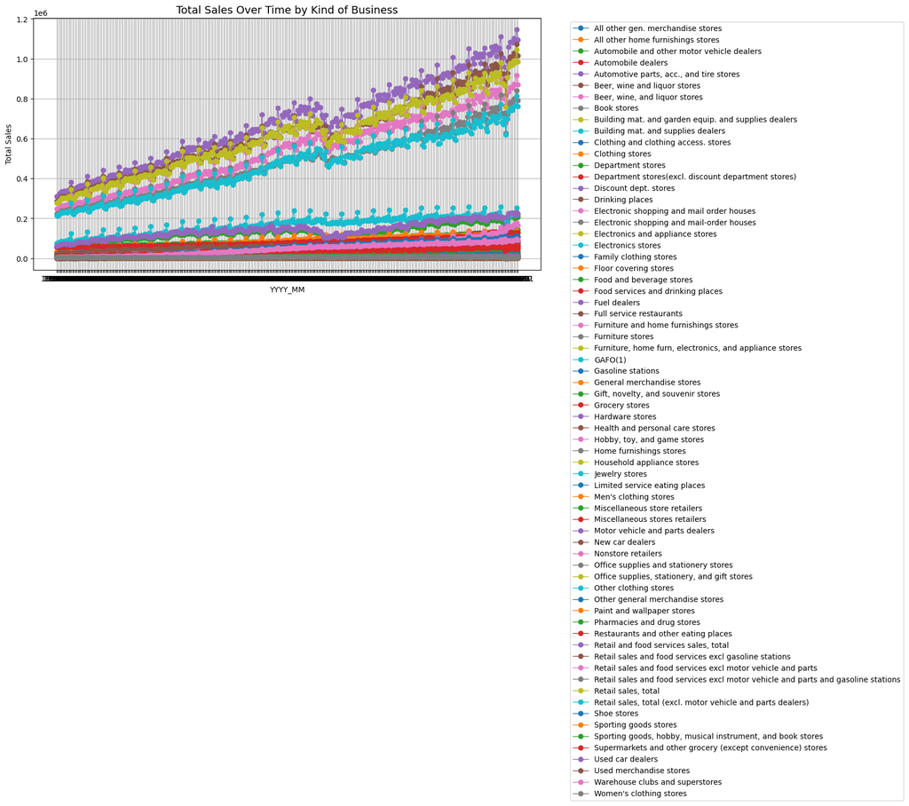

```python
plt.figure(figsize=(12,6))

# Plot sales for each business type separately
for business, subset in df.groupby("Kind of Business"):
    plt.plot(subset["YYYY_MM"], subset["Total_Sales"], marker="o", linewidth=1, label=business)

plt.title("Total Sales Over Time by Kind of Business", fontsize=14)
plt.xlabel("YYYY_MM")
plt.ylabel("Total Sales")
plt.grid(True)
plt.legend(bbox_to_anchor=(1.05, 1), loc="upper left")  # legend outside
plt.tight_layout()
plt.show()
```

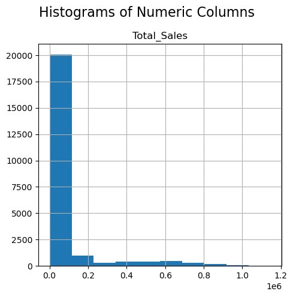

```python
import matplotlib.pyplot as plt

# Select only numeric columns
num_cols = df.select_dtypes(include=["int64", "float64"]).columns

# Plot histograms
df[num_cols].hist(figsize=(5,5))
plt.suptitle("Histograms of Numeric Columns", fontsize=16)
plt.tight_layout()
plt.show()
```

Insights from Histogram of Total Sales

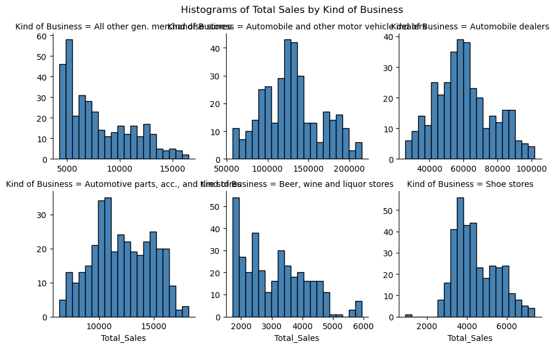

```python
import matplotlib.pyplot as plt
import seaborn as sns

# Pick top 6 businesses by frequency
top_business = df["Kind of Business"].value_counts().nlargest(6).index
subset = df[df["Kind of Business"].isin(top_business)]

# Plot histograms by business type
g = sns.FacetGrid(subset, col="Kind of Business", col_wrap=3, height=3, sharex=False, sharey=False)
g.map(plt.hist, "Total_Sales", bins=20, color="steelblue", edgecolor="black")
g.fig.subplots_adjust(top=0.9)
g.fig.suptitle("Histograms of Total Sales by Kind of Business")
plt.show()
```

Insights by Business Category

```
All other general merchandise stores
- Sales are mostly low, concentrated between 4,000–10,000, with a long right tail.
- Indicates many small stores with only a few generating higher sales.

Automobile & other motor vehicle dealers
- Much higher sales levels, with most values between 100,000–150,000.
- Distribution is fairly centered, suggesting more consistency compared to other categories.

Automobile dealers
- Sales mostly range from 40,000–80,000.
- Shows a bell-like distribution, meaning sales values are more normally distributed.

Automotive parts, accessories, and tire stores
- Concentrated around 10,000–15,000, with a balanced spread.
- Indicates steady but mid-level sales performance.

Beer, wine, and liquor stores
- Sales mainly between 2,000–4,500.
- Smaller scale compared to auto-related businesses but consistent demand is visible.

Shoe stores
- Clustered tightly between 3,000–6,000, with fewer extreme values.
- Suggests a more stable sales range across the category.
```

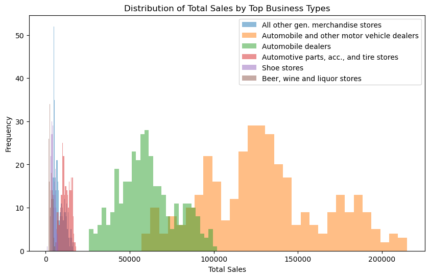

```python
plt.figure(figsize=(10,6))

for business in top_business:
    subset = df[df["Kind of Business"] == business]
    plt.hist(subset["Total_Sales"], bins=30, alpha=0.5, label=business)

plt.title("Distribution of Total Sales by Top Business Types")
plt.xlabel("Total Sales")
plt.ylabel("Frequency")
plt.legend()
plt.show()
```

### Intermediate File

```python
# Sample
sample_df = df.head(20)
sample_df.to_csv("mrtssales_sample.csv", index=False)
```

```python
# Full
df.to_csv("full_mrtssales.csv", index=False)
```

Back to top

### 2.4.1 Reading Sample Data (Installation File)

Before working with the full MRTS dataset, I created a small sample CSV containing only a few rows and selected columns. This allowed me to test my script quickly without processing the entire file. Using pandas.read_csv(), I confirmed that the script correctly imported the data, displayed column names, and handled basic formatting. This step ensured my code was working before moving on to the full dataset.

```python
# import pandas as pd
# mrt_data_sample = pd.read_csv("mrtssales_sample.csv")
# print(mrt_data_sample)
```

Basic CSV reader example in Python Example

```python
import csv

# open file
with open("mrtssales_sample.csv") as csv_file:
    # read csv file
    csv_reader = csv.reader(csv_file, delimiter=",")

    # loop through data
    for row in csv_reader:
        print(row)
```

```
['Kind of Business', 'YYYY_MM', 'Total_Sales']
['All other gen. merchandise stores', '1992-01', '4793.0']
['All other gen. merchandise stores', '1992-02', '4770.0']
['All other gen. merchandise stores', '1992-03', '4722.0']
['All other gen. merchandise stores', '1992-04', '4968.0']
['All other gen. merchandise stores', '1992-05', '4993.0']
['All other gen. merchandise stores', '1992-06', '4826.0']
['All other gen. merchandise stores', '1992-07', '4856.0']
['All other gen. merchandise stores', '1992-08', '4970.0']
['All other gen. merchandise stores', '1992-09', '4803.0']
['All other gen. merchandise stores', '1992-10', '5142.0']
['All other gen. merchandise stores', '1992-11', '5459.0']
['All other gen. merchandise stores', '1992-12', '7081.0']
['All other gen. merchandise stores', '1993-01', '4710.0']
['All other gen. merchandise stores', '1993-02', '4828.0']
['All other gen. merchandise stores', '1993-03', '5077.0']
['All other gen. merchandise stores', '1993-04', '5251.0']
['All other gen. merchandise stores', '1993-05', '5393.0']
['All other gen. merchandise stores', '1993-06', '5206.0']
['All other gen. merchandise stores', '1993-07', '5289.0']
['All other gen. merchandise stores', '1993-08', '5228.0']
```

Back to top

### 2.4.2 Reading the MRTS Data

Once the script worked on the sample, I applied the same method to the cleaned MRTS CSV file. Using:

```python
import pandas as pd

# Read the full MRTS dataset
mrt_data_full = pd.read_csv("full_mrtssales.csv")

# Preview the first 10 rows
print(mrt_data_full.head(10))

# Show summary info
print(mrt_data_full.info())
```

```
                    Kind of Business  YYYY_MM  Total_Sales
0  All other gen. merchandise stores  1992-01       4793.0
1  All other gen. merchandise stores  1992-02       4770.0
2  All other gen. merchandise stores  1992-03       4722.0
3  All other gen. merchandise stores  1992-04       4968.0
4  All other gen. merchandise stores  1992-05       4993.0
5  All other gen. merchandise stores  1992-06       4826.0
6  All other gen. merchandise stores  1992-07       4856.0
7  All other gen. merchandise stores  1992-08       4970.0
8  All other gen. merchandise stores  1992-09       4803.0
9  All other gen. merchandise stores  1992-10       5142.0
<class 'pandas.core.frame.DataFrame'>
RangeIndex: 23136 entries, 0 to 23135
Data columns (total 3 columns):
 #   Column            Non-Null Count  Dtype
---  ------            --------------  -----
 0   Kind of Business  23136 non-null  object
 1   YYYY_MM           23136 non-null  object
 2   Total_Sales       23136 non-null  float64
dtypes: float64(1), object(2)
memory usage: 542.4+ KB
None
```

Back to top

### 2.5 Writing an Installation Script

To integrate Python with MySQL Workbench, I wrote a script using the mysql.connector library. The script connects to the MySQL server, creates a table with the proper schema, and then loads the CSV data into the table row by row. I first tested the script with the sample dataset to verify the connection and table creation. After confirming, I ran the script on the full MRTS dataset, successfully installing the cleaned data into MySQL for future SQL queries and time-series analysis.

#### Option A - Anaconda to Workbench

```python
# # install_mrts_mysql.py
# import pandas as pd
# import mysql.connector as mc

# ---- Config ----
CSV_PATH = "full_mrtssales.csv"   # columns: Kind of Business, YYYY_MM, Total_Sales
DB_HOST  = "localhost"
DB_PORT  = 3306
DB_USER  = "root"
DB_PASS  = "root"
DB_NAME  = "db_mrts"
TABLE    = "mrts"

def main():
    # 1) Read CSV and validate columns
    df = pd.read_csv(CSV_PATH)
    expected = {"Kind of Business", "YYYY_MM", "Total_Sales"}
    missing = expected - set(df.columns)
    if missing:
        raise ValueError(f"CSV is missing columns: {missing}")

    # 2) Normalize/clean types
    df["Kind of Business"] = df["Kind of Business"].astype(str).str.strip()
    df["YYYY_MM"] = df["YYYY_MM"].astype(str).str.strip()
    df["Total_Sales"] = pd.to_numeric(df["Total_Sales"], errors="coerce")
    df = df.where(pd.notnull(df), None)  # NaN -> None for MySQL NULLs

    # 3) Ensure database exists
    root = mc.connect(host=DB_HOST, port=DB_PORT, user=DB_USER, password=DB_PASS)
    rc = root.cursor()
    rc.execute(f"CREATE DATABASE IF NOT EXISTS `{DB_NAME}` "
               f"DEFAULT CHARACTER SET utf8mb4 COLLATE utf8mb4_unicode_ci")
    rc.close(); root.close()

    # 4) Connect to target DB
    conn = mc.connect(host=DB_HOST, port=DB_PORT, user=DB_USER,
                      password=DB_PASS, database=DB_NAME)
    cur = conn.cursor()

    # 5) Drop & (re)create table with TEXT column
    cur.execute(f"DROP TABLE IF EXISTS `{TABLE}`")
    cur.execute(f"""
        CREATE TABLE `{TABLE}` (
          kind_of_business  TEXT,
          yyyy_mm           CHAR(7) NOT NULL,
          total_sales       DECIMAL(18,2),
          -- index prefix lets us enforce uniqueness & keep performance
          PRIMARY KEY (kind_of_business(100), yyyy_mm)
        ) ENGINE=InnoDB
          DEFAULT CHARSET=utf8mb4
          COLLATE=utf8mb4_unicode_ci
    """)
    conn.commit()

    # 6) Bulk insert (order must match INSERT)
    rows = list(df[["Kind of Business", "YYYY_MM", "Total_Sales"]]
                .itertuples(index=False, name=None))
    cur.executemany(
        f"INSERT INTO `{TABLE}` (kind_of_business, yyyy_mm, total_sales) "
        f"VALUES (%s, %s, %s)",
        rows
    )
    conn.commit()

    # 7) Quick sanity checks
    cur.execute(f"SELECT COUNT(*) FROM `{TABLE}`")
    print("Row count:", cur.fetchone()[0])
    cur.execute(f"SELECT * FROM `{TABLE}` ORDER BY yyyy_mm DESC LIMIT 5")
    for r in cur.fetchall():
        print(r)

    cur.close(); conn.close()

if __name__ == "__main__":
    main()
```

```
Row count: 23136
("Women's clothing stores", '2021-01', Decimal('4808.00'))
('Warehouse clubs and superstores', '2021-01', Decimal('93011.00'))
('Used merchandise stores', '2021-01', Decimal('1385.00'))
('Used car dealers', '2021-01', Decimal('10509.00'))
('Retail sales and food services excl motor vehicle and parts and gasoline stations', '2021-01', Decimal('791142.00'))
```

```python
# # Verify in MySQL Workbench (SQL tab

# USE db_mrts;
# SELECT COUNT(*) FROM mrts;
# SELECT * FROM mrts ORDER BY yyyy_mm DESC LIMIT 10;
```

[figure not shown]

#### Option B — Run as a standalone Python file

- A script like install_mrts_mysql.py that you run from Anaconda Prompt or any terminal.
- Reads CSV with pandas → connects with mysql.connector → creates the database/table → inserts rows.
- This is the “full-featured” Python method.
- Create a file named install_mrts_mysql.py next to your full_mrtssales.csv.
- Put this exact code in it:

```python
# # install_mrts_mysql.py
# # Purpose: Load full_mrtssales.csv (3 columns: Kind of Business, YYYY_MM, Total_Sales) into MySQL.

# import pandas as pd
# import mysql.connector as mc

# # ---------- Config ----------
# CSV_PATH = "full_mrtssales.csv"   # <-- 3-column CSV
# DB_HOST  = "localhost"
# DB_PORT  = 3306
# DB_USER  = "root"
# DB_PASS  = "root"                 # <-- change if needed
# DB_NAME  = "db_mrts"
# TABLE    = "mrts"
# # ----------------------------

# def main():
#     # 1) Read CSV
#     df = pd.read_csv(CSV_PATH)

#     # Expect 3 columns
#     expected_cols = {"Kind of Business", "YYYY_MM", "Total_Sales"}
#     missing = expected_cols - set(df.columns)
#     if missing:
#         raise ValueError(f"CSV is missing columns: {missing}")

#     # Normalize types
#     df["Kind of Business"] = df["Kind of Business"].astype(str).str.strip()
#     df["YYYY_MM"] = df["YYYY_MM"].astype(str).str.strip()             # e.g., '2021-01'
#     df["Total_Sales"] = pd.to_numeric(df["Total_Sales"], errors="coerce")
#     df = df.where(pd.notnull(df), None)                               # NaN -> None (MySQL NULL)

#     # 2) Ensure database exists (utf8mb4)
#     root_conn = mc.connect(host=DB_HOST, port=DB_PORT, user=DB_USER, password=DB_PASS)
#     root_cur  = root_conn.cursor()
#     root_cur.execute(
#         f"CREATE DATABASE IF NOT EXISTS `{DB_NAME}` "
#         f"DEFAULT CHARACTER SET utf8mb4 COLLATE utf8mb4_unicode_ci"
#     )
#     root_cur.close(); root_conn.close()

#     # 3) Connect to target DB
#     conn = mc.connect(host=DB_HOST, port=DB_PORT, user=DB_USER, password=DB_PASS, database=DB_NAME)
#     cur  = conn.cursor()

#     # 4) Recreate table with TEXT business name (no truncation)
#     cur.execute(f"DROP TABLE IF EXISTS `{TABLE}`")
#     cur.execute(f"""
#         CREATE TABLE `{TABLE}` (
#           kind_of_business  TEXT,
#           yyyy_mm           CHAR(7) NOT NULL,     -- 'YYYY-MM'
#           total_sales       DECIMAL(18,2),
#           PRIMARY KEY (kind_of_business(100), yyyy_mm)  -- index prefix; full TEXT is preserved
#         ) ENGINE=InnoDB
#           DEFAULT CHARSET=utf8mb4
#           COLLATE=utf8mb4_unicode_ci;
#     """)
#     conn.commit()

#     # 5) Bulk insert
#     rows = list(df[["Kind of Business", "YYYY_MM", "Total_Sales"]].itertuples(index=False, name=None))
#     cur.executemany(
#         f"INSERT INTO `{TABLE}` (kind_of_business, yyyy_mm, total_sales) VALUES (%s, %s, %s)",
#         rows
#     )
#     conn.commit()
#     print(f"Loaded {cur.rowcount} rows into {DB_NAME}.{TABLE}")

#     # 6) Quick verification
#     cur.execute(f"SELECT COUNT(*) FROM `{TABLE}`")
#     print("Row count:", cur.fetchone()[0])

#     cur.execute(f"SELECT * FROM `{TABLE}` ORDER BY yyyy_mm DESC LIMIT 5")
#     for r in cur.fetchall():
#         print(r)

#     cur.close(); conn.close()

# if __name__ == "__main__":
#     main()
```

```python
# Open Anaconda Prompt
pip install mysql-connector-python

# Save the script above as install_mrts_mysql.py in the same folder as full_mrtssales.csv.

# Run

python install_mrts_mysql.py
```

[output not shown]

```python
# Verify in MySQL Workbench
```

```python
# USE db_mrts;

# SELECT COUNT(*) FROM mrts;

# SELECT *
# FROM mrts
# ORDER BY yyyy_mm DESC
# LIMIT 10;
```

#### Option C —Run in Visual Studio Code Terminal

- A simpler script like install_mrts_simple.py that does basically the same, but you run it from VS Code’s terminal (Ctrl + backtick).
- Same libraries (mysql.connector, pandas) but lighter.
- Open VS Code.
- Create a new file named install_mrts_simple.py.

```python
# # # install_mrts_simple.py
# # # Purpose: Load full_mrtssales.csv into MySQL (3 columns: Kind of Business, YYYY_MM, Total_Sales)

# # import pandas as pd
# # import mysql.connector as mc

# # ---------- Config ----------
# CSV_PATH = "full_mrtssales.csv"   # CSV file (must be in same folder as script)
# DB_HOST  = "localhost"
# DB_USER  = "root"
# DB_PASS  = "root"
# DB_NAME  = "db_mrts"
# TABLE    = "mrts"
# # ----------------------------

# # --- Read CSV ---
# df = pd.read_csv(CSV_PATH)

# # Expect required columns
# expected = {"Kind of Business", "YYYY_MM", "Total_Sales"}
# missing = expected - set(df.columns)
# if missing:
#     raise ValueError(f"CSV is missing columns: {missing}")

# # --- Normalize types ---
# df["Kind of Business"] = df["Kind of Business"].astype(str).str.strip()
# df["YYYY_MM"] = df["YYYY_MM"].astype(str).str.strip()
# df["Total_Sales"] = pd.to_numeric(df["Total_Sales"], errors="coerce")
# df = df.where(pd.notnull(df), None)  # replace NaN with None (MySQL NULL)

# # --- Ensure database exists ---
# conn = mc.connect(host=DB_HOST, user=DB_USER, password=DB_PASS)
# cur = conn.cursor()
# cur.execute(
#     f"CREATE DATABASE IF NOT EXISTS `{DB_NAME}` "
#     f"DEFAULT CHARACTER SET utf8mb4 COLLATE utf8mb4_unicode_ci"
# )
# conn.commit()
# cur.close(); conn.close()

# # --- Reconnect to target DB ---
# conn = mc.connect(host=DB_HOST, user=DB_USER, password=DB_PASS, database=DB_NAME)
# cur = conn.cursor()

# # --- Drop & create table ---
# cur.execute(f"DROP TABLE IF EXISTS `{TABLE}`")
# cur.execute(f"""
#     CREATE TABLE `{TABLE}` (
#       kind_of_business  TEXT,
#       yyyy_mm           CHAR(7) NOT NULL,
#       total_sales       DECIMAL(18,2),
#       PRIMARY KEY (kind_of_business(100), yyyy_mm)  -- index prefix; full TEXT preserved
#     ) ENGINE=InnoDB
#       DEFAULT CHARSET=utf8mb4
#       COLLATE=utf8mb4_unicode_ci
# """)
# conn.commit()

# # --- Bulk insert ---
# rows = list(df[["Kind of Business", "YYYY_MM", "Total_Sales"]].itertuples(index=False, name=None))
# cur.executemany(
#     f"INSERT INTO `{TABLE}` (kind_of_business, yyyy_mm, total_sales) VALUES (%s, %s, %s)",
#     rows
# )
# conn.commit()

# print(f"✅ Done — loaded {cur.rowcount} rows into {DB_NAME}.{TABLE}")

# cur.close(); conn.close()
```

```python
# # Open VS Code terminal (Ctrl+`) and run:

# pip install mysql-connector-python pandas
# python install_mrts_simple.py
```

```python
# # Then check results in MySQL Workbench with:
# USE db_mrts;
# SELECT COUNT(*) FROM mrts;
```

#### Option D — Run in MySQL Workbench’s Built-in Terminal

- Here you don’t touch Python at all.
- You use pure SQL with the LOAD DATA INFILE command.
- This only works if MySQL Server has access to the CSV path.
- Example from your commented-out section:
- MySQL Workbench itself does not run Python directly, but you can:
  - Use its System Shell / External Tool integration, OR
  - Use Workbench’s SQL Editor for raw SQL (e.g., LOAD DATA INFILE).

```python
# -- Step 1: Create database and table
# CREATE DATABASE IF NOT EXISTS db_mrts
#   DEFAULT CHARACTER SET utf8mb4
#   COLLATE utf8mb4_unicode_ci;
# USE db_mrts;

# DROP TABLE IF EXISTS mrts;
# CREATE TABLE mrts (
#   kind_of_business  TEXT,
#   yyyy_mm           CHAR(7) NOT NULL,
#   total_sales       DECIMAL(18,2),
#   PRIMARY KEY (kind_of_business(100), yyyy_mm)   -- index prefix for performance
# ) ENGINE=InnoDB
#   DEFAULT CHARSET=utf8mb4
#   COLLATE=utf8mb4_unicode_ci;

# -- Step 2: Load CSV (adjust path to where your CSV is located)
# LOAD DATA INFILE 'C:/path/to/full_mrtssales.csv'
# INTO TABLE mrts
# FIELDS TERMINATED BY ','
# OPTIONALLY ENCLOSED BY '"'
# LINES TERMINATED BY '\n'
# IGNORE 1 ROWS
# (kind_of_business, yyyy_mm, total_sales);
```

Note: For LOAD DATA INFILE to work, you may need to:

Move your CSV to a MySQL-accessible folder (C:/ProgramData/MySQL/MySQL Server 8.0/Uploads).

Or use LOAD DATA LOCAL INFILE if the server allows local files.

C.1 → Run a short Python .py script in VS Code terminal (very simple, keeps Python + pandas). C.2 → Skip Python entirely and just use Workbench SQL (LOAD DATA INFILE).

Back to top

## 3. Analysis and Visualization

**MySQL Workbench**

- Advantages:
  - Provides a graphical environment to directly test SQL queries.
  - Easy to preview raw tables, counts, and filtered results.
  - Great for verifying that data has been loaded correctly into the database.
- Disadvantages:
  - Limited visualization options. Results are displayed in tables only.
  - More difficult to calculate advanced metrics (e.g., rolling averages) without complex SQL.

**Python (using mysql.connector + pandas + matplotlib)**

- Advantages:
  - Queries can be automated, reused, and combined with data transformations in Pandas.
  - Powerful visualization with Matplotlib and Seaborn (e.g., line charts, bar plots).
  - Easier to calculate advanced analytics such as percentage change, trends, and rolling windows.
- Disadvantages:
  - Requires extra setup (connection libraries, credentials).
  - Code-based approach may be slower for simple validation compared to Workbench.

Back to top

### 3.1 Running Queries in MySQL Workbech

**A.** Check the total number of rows inserted

- To verify that the MRTS dataset was successfully loaded into MySQL

[figure not shown]

```
- This confirmed that the number of rows matched the dataset I exported from Python
- The COUNT(*) query confirmed that the dataset was fully imported.
```

**B.** Preview the most recent months of data

[figure not shown]

```
- This allowed me to check that the yyyy_mm column was correctly formatted as YYYY-MM and that sales figures were numeric.
```

**C.** Check distinct categories of businesses

[figure not shown]

```
- This verified that the “Kind of Business” column contained all expected categories rather than repeating one value.
- The DISTINCT query confirmed multiple categories were present
```

Back to top

### 3.2 Running Queries From Python

**install_mrts_mysql.py**

````
#
# Purpose: Load full_mrtssales.csv (Kind of Business, YYYY_MM, Total_Sales) into MySQL
import pandas as pd
import mysql.connector as mc

# ---------- Config ----------
CSV_PATH = "full_mrtssales.csv"
DB_HOST  = "localhost"
DB_PORT  = 3306
DB_USER  = "root"
DB_PASS  = "root"   # change if you set a different MySQL password
DB_NAME  = "db_mrts"
TABLE    = "mrts"
# ----------------------------

def main():
    # 1) Read CSV
    df = pd.read_csv(CSV_PATH)

    # Expect required columns
    expected_cols = {"Kind of Business", "YYYY_MM", "Total_Sales"}
    missing = expected_cols - set(df.columns)
    if missing:
        raise ValueError(f"CSV is missing columns: {missing}")

    # Normalize
    df["Kind of Business"] = df["Kind of Business"].astype(str).str.strip()
    df["YYYY_MM"] = df["YYYY_MM"].astype(str).str.strip()
    df["Total_Sales"] = pd.to_numeric(df["Total_Sales"], errors="coerce")
    df = df.where(pd.notnull(df), None)

    # 2) Ensure database exists
    root_conn = mc.connect(host=DB_HOST, port=DB_PORT, user=DB_USER, password=DB_PASS)
    root_cur  = root_conn.cursor()
    root_cur.execute(f"CREATE DATABASE IF NOT EXISTS `{DB_NAME}`")
    root_cur.close(); root_conn.close()

    # 3) Connect to target DB
    conn = mc.connect(host=DB_HOST, port=DB_PORT, user=DB_USER, password=DB_PASS, database=DB_NAME)
    cur  = conn.cursor()

    # 4) Recreate table
    cur.execute(f"DROP TABLE IF EXISTS `{TABLE}`")
    cur.execute(f"""
        CREATE TABLE `{TABLE}` (
          kind_of_business TEXT,
          yyyy_mm CHAR(7) NOT NULL,
          total_sales DECIMAL(18,2)
        );
    """)

    # 5) Bulk insert
    rows = list(df[["Kind of Business", "YYYY_MM", "Total_Sales"]].itertuples(index=False, name=None))
    cur.executemany(
        f"INSERT INTO `{TABLE}` (kind_of_business, yyyy_mm, total_sales) VALUES (%s, %s, %s)",
        rows
    )
    conn.commit()

    print(f"Loaded {cur.rowcount} rows into {DB_NAME}.{TABLE}")

    # 6) Verification
    cur.execute(f"SELECT COUNT(*) FROM `{TABLE}`")
    print("Row count:", cur.fetchone()[0])

    cur.execute(f"SELECT * FROM `{TABLE}` ORDER BY yyyy_mm DESC LIMIT 5")
    for r in cur.fetchall():
        print(r)

    cur.close(); conn.close()

if __name__ == "__main__":
    main()```
````

[figure not shown]

**query_mrts.py**

Retail and Food Services Sales Over Time Series Plot

[output not shown]

[figure not shown]

- Clear long-run upward trend with occasional cyclical dips/spikes (holiday peaks visible).
- Noticeable disruption around 2020 followed by a sharp recovery.
- Confirms end-to-end pipeline: SQL → Python → Matplotlib worked as expected.

Back to top

### 3.3 Explore Trends

An economic trend refers to the long-term direction or movement of economic indicators, like spending patterns. It is important because it helps predict future performance and guide decision-making in business, government, and finance. Understanding trends like these allows companies to forecast demand and adjust their strategies accordingly.

The trend of retail and food services sales clearly shows a steady upward movement, especially in the latter years. Monthly data helps reveal fluctuations caused by seasonal events like holidays. By aggregating the data annually, we can better understand the underlying growth and identify patterns that may not be visible in the noisy monthly data.

By comparing various businesses, we can evaluate the growth rates and trends over time:

Which is better for visualizing the trends—Monthly or Yearly?

- Monthly data is useful for spotting short-term fluctuations but can be noisy.
- Yearly data is better for long-term trends and gives a clearer view of the overall trajectory of each business category.

Single category monthly trend

[figure not shown]

This query aggregates the total sales by month, allowing us to observe how sales have fluctuated over time.

The trend in monthly sales can be easily displayed, but it needs some cleaning for extraneous details. However, even without adjustments, a clear upward trend is visible, reflecting steady growth.

Same category yearly trend

[figure not shown]

This query groups the data by year, providing a clearer overview of sales trends over time while reducing noise from seasonal fluctuations. The result is a much smoother trend line, which makes it easier to identify long-term growth or decline

By grouping sales data by year, we can better identify long-term growth patterns. The annual data also smooths out monthly fluctuations and makes trends more interpretable, particularly for forecasting.

Yearly Sales Trend: Book vs Sporting vs Hobby/Toy/Game

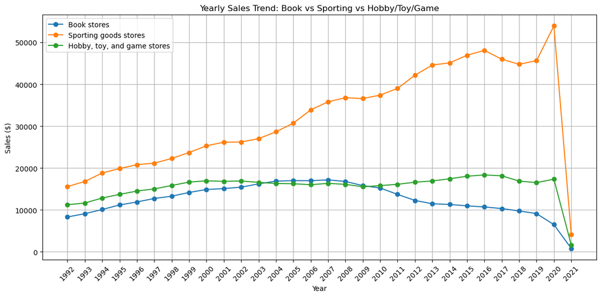

```python
import mysql.connector as mc
import matplotlib.pyplot as plt
from collections import defaultdict

DB = dict(host="localhost", user="root", password="root", database="db_mrts")

sql = """
SELECT kind_of_business, LEFT(yyyy_mm, 4) AS yyyy, SUM(total_sales) AS sales
FROM mrts
WHERE kind_of_business IN ('Book stores','Sporting goods stores','Hobby, toy, and game stores')
GROUP BY kind_of_business, LEFT(yyyy_mm, 4)
ORDER BY kind_of_business, yyyy;
"""

cn = mc.connect(**DB); cur = cn.cursor()
cur.execute(sql)
rows = cur.fetchall()
cur.close(); cn.close()

# Shape into series per business
series = defaultdict(list)
years  = sorted({r[1] for r in rows})
by_key = {(k,y): s for (k,y,s) in rows}

labels = ['Book stores','Sporting goods stores','Hobby, toy, and game stores']

plt.figure(figsize=(12,6))
for lab in labels:
    yvals = [float(by_key.get((lab, y), 0.0)) for y in years]
    plt.plot(years, yvals, marker="o", label=lab)

plt.title("Yearly Sales Trend: Book vs Sporting vs Hobby/Toy/Game")
plt.xlabel("Year"); plt.ylabel("Sales ($)")
plt.xticks(rotation=45)
plt.grid(True); plt.legend(); plt.tight_layout(); plt.show()
```

Book Stores

- Initially grew steadily from 1992 through early 2000s, peaking around 2007–2008 (~$17,000).
- Declined continuously afterward, reflecting the shift toward digital reading, e-commerce (Amazon), and declining physical book retail sales.
- By 2020–2021, book store sales dropped to their lowest point in the series.

Back to top

### 3.4 Explore Percentage Change

What is percentage change and why is it important?**

- In economics, percentage change measures the relative increase or decrease of a variable compared to its past value. It is crucial because it shows the *rate of growth or decline* rather than absolute amounts. For retail spending patterns, percentage change highlights how consumer demand evolves over time, making it easier to compare different categories with varying sales scales. This is especially useful for detecting economic shocks (e.g., recessions or COVID-19) and for forecasting future trends.

Analysis of Women's vs Men's Clothing Stores

- I wrote SQL queries that aggregated sales for women’s and men’s clothing stores, then calculated:
  - **Year-over-Year (YoY) percentage change** to measure growth/decline trends.
  - **Contribution shares**: the proportion of each category’s sales compared to the total retail & food services sales.

Findings:

- Women’s Clothing Stores
  - Historically contributed more to total retail sales (~1.5% in the early 1990s).
  - Share steadily declined to ~0.5–0.7% by 2019.
  - Suffered a sharp contraction in 2020, dropping close to zero due to the pandemic.
  - Shows more frequent positive short-term growth spikes, suggesting resilience in recovery periods.
- Men’s Clothing Stores
  - Always a smaller share (~0.5% in early 1990s, falling below 0.2% by 2019).
  - Declined more gradually than women’s, but also dropped sharply in 2020.
  - More vulnerable to downturns, with deeper negative swings in YoY percentage change compared to women’s.

Insights:

- Both categories lost relative importance over time within the broader retail sector.
- Women’s clothing, while larger historically, saw a steady long-term decline and then collapsed during 2020.
- Men’s clothing sales were consistently smaller and also declined, reflecting structural shifts in consumer spending.
- Percentage change analysis highlights that **women’s clothing is slightly more resilient** in upturns, while **men’s clothing is more exposed to downturns**.
- Both categories demonstrate how external shocks (like the COVID-19 pandemic) accelerate existing downward trends.

Percentage change provides a normalized view of growth dynamics. It clearly shows that women’s and men’s clothing stores have both lost share within the retail economy, but women’s stores experienced sharper declines in contribution, while men’s stores remained a consistently small segment throughout the observed period.

Get monthly series with total for shares

[output not shown]

[figure not shown]

Compute YoY % change and plot shares + pct change

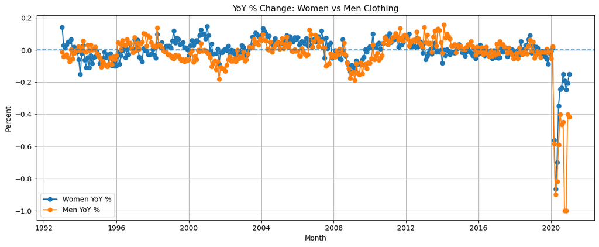

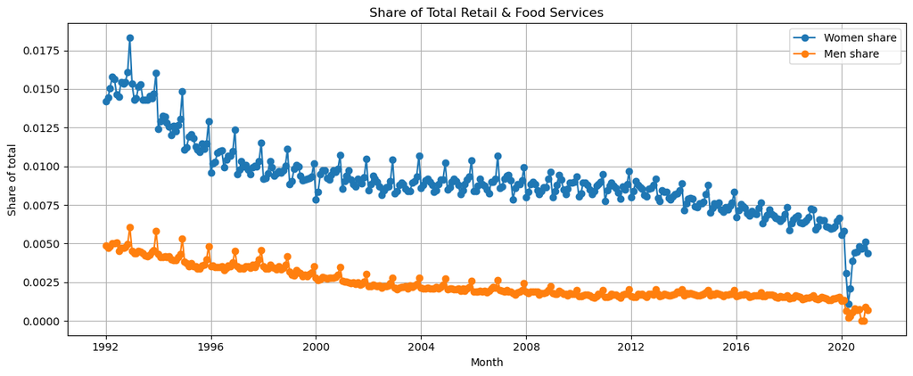

```python
import mysql.connector as mc
import pandas as pd
import matplotlib.pyplot as plt

DB = dict(host="localhost", user="root", password="root", database="db_mrts")

sql = """
WITH base AS (
  SELECT
    yyyy_mm,
    SUM(CASE WHEN kind_of_business = "Women's clothing stores" THEN total_sales ELSE 0 END) AS womens,
    SUM(CASE WHEN kind_of_business = "Men's clothing stores"   THEN total_sales ELSE 0 END) AS mens,
    SUM(total_sales) AS total_all
  FROM mrts
  WHERE kind_of_business IN ("Women's clothing stores","Men's clothing stores")
     OR kind_of_business = 'Retail and food services sales, total'
  GROUP BY yyyy_mm
)
SELECT yyyy_mm, womens, mens, total_all
FROM base
ORDER BY yyyy_mm;
"""

cn = mc.connect(**DB); cur = cn.cursor()
cur.execute(sql)
rows = cur.fetchall()
cur.close(); cn.close()

df = pd.DataFrame(rows, columns=["yyyy_mm","womens","mens","total_all"])
df["yyyy_mm"] = pd.to_datetime(df["yyyy_mm"], format="%Y-%m")

# YoY % change (12-month lag)
df = df.sort_values("yyyy_mm").reset_index(drop=True)
for c in ["womens","mens"]:
    df[c+"_pct_yoy"] = df[c].pct_change(12)

# Contribution shares
df["womens_share"] = df["womens"] / df["total_all"]
df["mens_share"]   = df["mens"]   / df["total_all"]

# Plot YoY %
plt.figure(figsize=(12,5))
plt.plot(df["yyyy_mm"], df["womens_pct_yoy"], marker="o", label="Women YoY %")
plt.plot(df["yyyy_mm"], df["mens_pct_yoy"], marker="o", label="Men YoY %")
plt.axhline(0, linestyle="--")
plt.title("YoY % Change: Women vs Men Clothing")
plt.xlabel("Month"); plt.ylabel("Percent")
plt.legend(); plt.grid(True); plt.tight_layout(); plt.show()

# Plot contribution shares
plt.figure(figsize=(12,5))
plt.plot(df["yyyy_mm"], df["womens_share"], marker="o", label="Women share")
plt.plot(df["yyyy_mm"], df["mens_share"], marker="o", label="Men share")
plt.title("Share of Total Retail & Food Services")
plt.xlabel("Month"); plt.ylabel("Share of total")
plt.legend(); plt.grid(True); plt.tight_layout(); plt.show()
```

Graph 1 – YoY % Change: Women vs Men Clothing

- Overall Pattern: Both women’s and men’s clothing sales tend to hover close to 0% YoY change, which suggests relatively stable year-over-year sales most of the time.
- Fluctuations: Small positive and negative swings (±0.1 to ±0.2) indicate regular variability but no major volatility in most years.
- Shocks: Around 2020–2021, both categories plunged to -0.6 to -1.0 YoY change, reflecting a massive contraction (likely pandemic-related).
- Relative Movement:
  - Women’s clothing shows slightly more frequent positive spikes than men’s, indicating occasional stronger short-term growth.
  - Men’s clothing shows slightly deeper negative dips in some years, suggesting greater vulnerability to downturns.
- Insight: Women’s clothing is somewhat more resilient and shows more upward spikes, while men’s clothing has sharper downturns. Both categories suffered extreme declines around 2020.

Graph 2 – Share of Total Retail & Food Services

- Women’s Clothing Share:
- Started high (~1.5% of total retail & food services in the early 1990s).
- Shows a long-term decline, steadily falling toward 0.5%–0.7% by 2019, with a sharp collapse during 2020.
- Men’s Clothing Share:
  - Always smaller (~0.5% in early 1990s, trending down to <0.2%).
  - Declined more gradually than women’s, but also dropped to near zero in 2020.
- Overall: Both categories lost relative importance within total retail sales, especially women’s clothing, which had a much larger base but fell significantly over time.
- Insight: Women’s clothing contributed more historically but has steadily lost share, while men’s clothing has always been a small slice of retail sales. Both collapsed dramatically during 2020.

Back to top

### 3.5 Explore Rolling Time Windows

A rolling time window is a moving calculation (e.g., rolling average or sum) that smooths short-term fluctuations to reveal longer-term trends. In economics, it helps track persistent changes in spending while filtering out monthly volatility, making it useful for forecasting and policy insights.

I wrote SQL queries to calculate a 12-month rolling sum for two categories: Electronics and appliance stores and Grocery stores.

Monthly series with total for shares

Electronics and appliance stores and Grocery stores.

[output not shown]

[figure not shown]

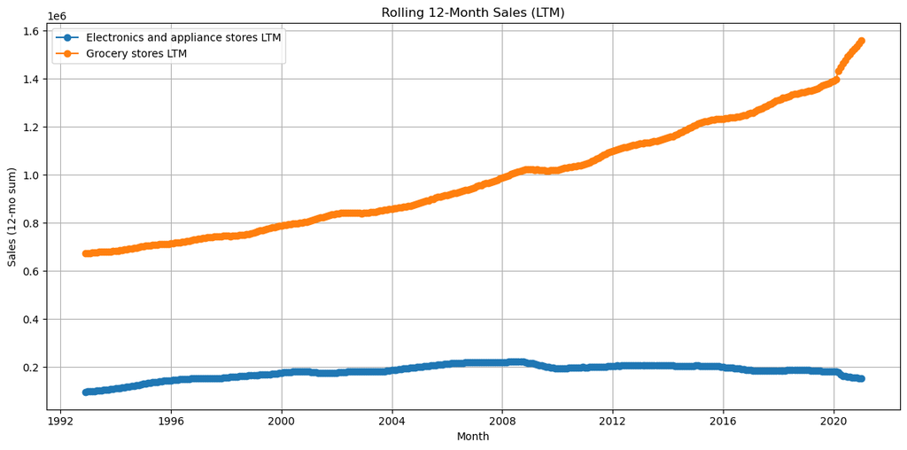

```python
import mysql.connector as mc
import pandas as pd
import matplotlib.pyplot as plt

CATS = ['Electronics and appliance stores','Grocery stores']
DB = dict(host="localhost", user="root", password="root", database="db_mrts")

sql = f"""
SELECT kind_of_business, yyyy_mm, SUM(total_sales) AS sales
FROM mrts
WHERE kind_of_business IN ({','.join(["%s"]*len(CATS))})
GROUP BY kind_of_business, yyyy_mm
ORDER BY kind_of_business, yyyy_mm;
"""

cn = mc.connect(**DB); cur = cn.cursor()
cur.execute(sql, CATS)
rows = cur.fetchall()
cur.close(); cn.close()

df = pd.DataFrame(rows, columns=["kind","yyyy_mm","sales"])
df["yyyy_mm"] = pd.to_datetime(df["yyyy_mm"])

# LTM (12-month rolling sum per series)
df = df.sort_values(["kind","yyyy_mm"])
df["ltm"] = df.groupby("kind")["sales"].rolling(12).sum().reset_index(level=0, drop=True)

# Plot LTM
plt.figure(figsize=(12,6))
for k, sub in df.groupby("kind"):
    plt.plot(sub["yyyy_mm"], sub["ltm"], marker="o", label=f"{k} LTM")
plt.title("Rolling 12-Month Sales (LTM)")
plt.xlabel("Month"); plt.ylabel("Sales (12-mo sum)")
plt.legend(); plt.grid(True); plt.tight_layout(); plt.show()
```

Grocery Stores (orange line):

- Sales show a steady, long-term upward trend across the entire period (1992–2021).
- Growth accelerated significantly after 2010, with especially sharp increases around 2020–2021 (likely reflecting pandemic-driven demand for groceries).
- By 2021, rolling annual grocery sales reached ~1.6M, showing sustained strength and resilience.

Electronics and Appliance Stores (blue line):

- Grew gradually in the 1990s, peaking around 2007–2008, then plateaued.
- After 2008, the trend flattened and eventually declined, with noticeable dips after 2015 and again around 2020.
- This suggests that consumer spending on electronics/appliances was more cyclical and sensitive to economic downturns.

Comparison:

Insight: Rolling 12-month windows highlight a clear divergence: grocery sales expand steadily with resilience, while electronics peak early and decline, showing more vulnerability to economic cycles and shifting consumer demand.

Back to top

## Conclusion

- **Highest growth**: Grocery stores demonstrated the most consistent and resilient long-term growth, especially after 2010 and during the pandemic years, showing their essential nature.
- **Declining categories**: Bookstores and electronics/appliance stores showed stagnation or decline, reflecting shifts in consumer preferences and the impact of digital alternatives.
- **Clothing categories**: Women’s clothing consistently contributed more to total retail than men’s clothing but declined steadily over time, with both suffering sharp drops in 2020.
- **Seasonality**: Many categories experienced regular seasonal spikes (e.g., holiday months), but yearly data provided clearer insights into long-term structural trends.
- **Rolling windows**: Long-term moving averages revealed underlying economic cycles, smoothing short-term volatility and highlighting which sectors are more stable (groceries) versus cyclical (electronics).

Back to top

## References

```python
#anaconda

import os, glob, pathlib
print("CWD:", pathlib.Path().resolve())
print("Notebooks here:", glob.glob("*.ipynb"))
```

```
CWD: C:\Users\ashwi\MIT DE\ETL MRTS
Notebooks here: ['Module 8_Final_Project_Template.ipynb']
```

```python
!jupyter nbconvert --to html "Module 8_Final_Project_Template.ipynb"
```